# Homework 7

Alejandro Rosales

December 2, 2019

### Variables

admit: 1 if student was admitted, 0 otherwise

gpa: the student’s undergraduate GPA

gre: the student’s GRE score (Note: the GRE changed its scoring several years ago. These are on the old scale, so they are out of 800.)

rank: a measure of the prestige of the graduate school to which the student is applying. These are scored 1-4, with 1 representing the most prestigious schools.

### Problems

Use the following steps to investigate potential predictive models for graduate school admission rates.

Read in the data. You should convert admit and rank to factors.

Exploratory data analysis: make side-by-side boxplots for each of the three predictors, grouped by whether or not they were admitted. Do there appear to be any patterns in the admission rates? (For this problem only, it is helpful to treat rank as numeric. You can use as.numeric(rank) in your plot aesthetic to do this.)

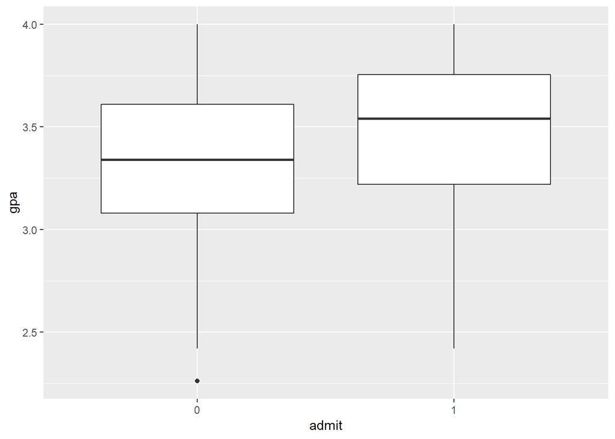

```r
ggplot(admissions, aes(x=admit, y=gpa)) + geom_boxplot()
```

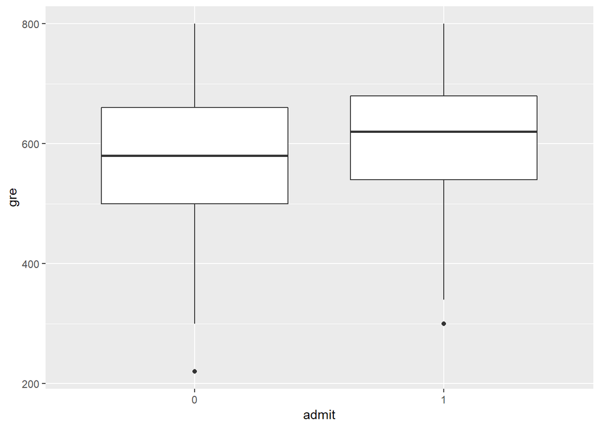

```r
ggplot(admissions, aes(x=admit, y=gre)) + geom_boxplot()
```

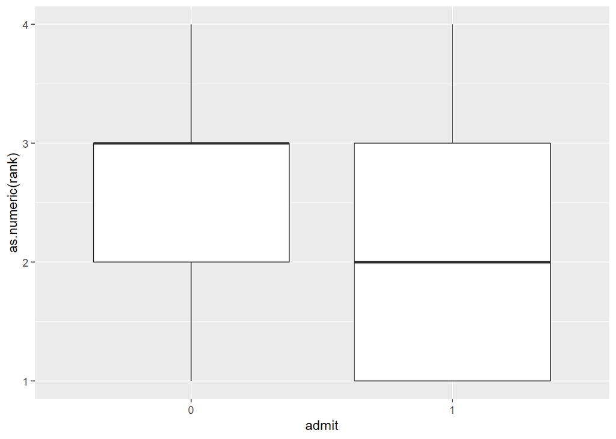

```r
ggplot(admissions, aes(x=admit, y=as.numeric(rank))) + geom_boxplot()
```

Fit the full main effects logistic regression model using all three predictors. Interpret the coefficients for each of the predictors in the context of the problem (including the intercept). (Hint: you may need to transform the coefficients for the interpretation to make sense.)

```r
admissions.fit <- glm(admit ~ gpa + gre + rank, data=admissions, family=binomial(link=logit))
exp(admissions.fit$coefficients)
```

```
## (Intercept)         gpa         gre       rank2       rank3       rank4
##   0.0185001   2.2345448   1.0022670   0.5089310   0.2617923   0.2119375
```

Use a full model test to determine whether the full model is predictive of admission rates. (Cite specific output from R.)

```r
null.model <- glm(admit ~ 1, data=admissions, family=binomial(link=logit))
anova(null.model, admissions.fit, test="LRT")
```

```
## Analysis of Deviance Table
##
## Model 1: admit ~ 1
## Model 2: admit ~ gpa + gre + rank
##   Resid. Df Resid. Dev Df Deviance  Pr(>Chi)
## 1       399     499.98
## 2       394     458.52  5   41.459 7.578e-08 ***
## ---
## Signif. codes:  0 '***' 0.001 '**' 0.01 '*' 0.05 '.' 0.1 ' ' 1
```

```r
#ASK
```

**I ran an anova test between the full model and null model. The full model is significant in predicting admission rate because the $p-value=7.578e-08$.**

Based on likelihood ratio tests, which predictors appear to be associated with admission rates? (Cite specific output from R.)

```r
anova(admissions.fit, test="LRT")
```

```
## Analysis of Deviance Table
##
## Model: binomial, link: logit
##
## Response: admit
##
## Terms added sequentially (first to last)
##
##
##      Df Deviance Resid. Df Resid. Dev  Pr(>Chi)
## NULL                   399     499.98
## gpa   1  13.0089       398     486.97   0.00031 ***
## gre   1   6.6236       397     480.34   0.01006 *
## rank  3  21.8265       394     458.52 7.088e-05 ***
## ---
## Signif. codes:  0 '***' 0.001 '**' 0.01 '*' 0.05 '.' 0.1 ' ' 1
```

```r
#ASK
```

**Based on the likelihood ratio test, all predictors appear to be statistically signficalty assoicated with admission rates as GPA $p-value=0.00031$, $p-value=0.01006$, $p-value=7.088e-05$.**

Add an interaction between GRE scores and GPA. Using a likelihood ratio test, determine whether this interaction is significant.

```r
interaction.model <- glm(admit ~ gpa + gre + rank + gpa:gre, data=admissions, family=binomial(link=logit))
anova(interaction.model, admissions.fit, test="LRT")
```

```
## Analysis of Deviance Table
##
## Model 1: admit ~ gpa + gre + rank + gpa:gre
## Model 2: admit ~ gpa + gre + rank
##   Resid. Df Resid. Dev Df Deviance Pr(>Chi)
## 1       393     455.77
## 2       394     458.52 -1  -2.7464  0.09747 .
## ---
## Signif. codes:  0 '***' 0.001 '**' 0.01 '*' 0.05 '.' 0.1 ' ' 1
```

**At a signficance level of 0.05, the interaction between gpa and gre is not signficant as $p-value=0.09747$.**

Use a 5-fold cross-validation to select the best combination of covariates to explain admittance rate. Try at least 3 different models to compare using cross-validation. To do generalized linear models in the caret package, you can use method=”glm” in the train() function. You will also need to specify family=”binomial”. Note that unlike in the glm() function, binomial must be in quotes. You will notice that we get different test statistics for logistic regression than we did with linear regression. For this problem, use “Accuracy” to evaluate these models. This is the prediction accuracy: how often do we correctly predict whether a student was admitted? As you can probably guess, higher prediction accuracy is better. Note: if you get an error message that package e1071 is needed, then simply install it using install.packages(). Remember to set a random seed so that your analysis is reproducible!

```r
set.seed(1337)
train_control <- trainControl(method="cv", number=5)
model1 <- train(admit ~ gpa + gre + rank, data=admissions, trControl=train_control, method="glm", family="binomial")
model2 <- train(admit ~ gpa + gre, data=admissions, trControl=train_control, method="glm", family="binomial")
model3 <- train(admit ~ gpa + gre + rank + gpa:gre, data=admissions, trControl=train_control, method="glm", family="binomial")

x <- summary(resamples(list(mod1 = model1,
                            mod2 = model2,
                            mod3 = model3)))$statistics
as.data.frame(x$Accuracy)[,4]
```

```
## [1] 0.7025000 0.6673953 0.7001809
```

**The model that preformed the best was the full fit model with an accuracy of 0.7025000.**